# Projekt_faza_3

## Analiza zwiedzających z poszczególnych klastrów (bez kolejności zwiedzania)

Przeprowadzimy teraz analizy dla klastrów 1-3 dla grupy gości odwiedzających 10-14 stacji.

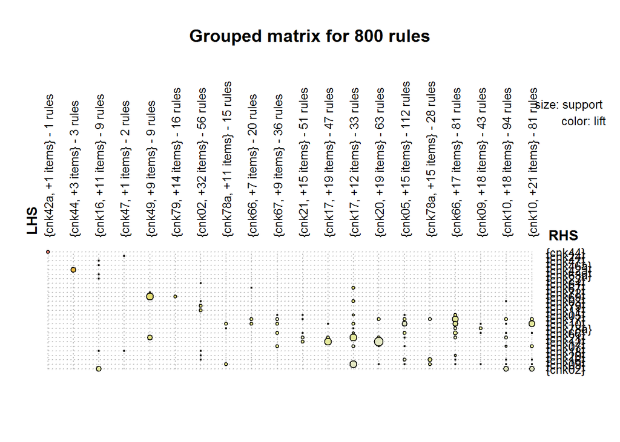

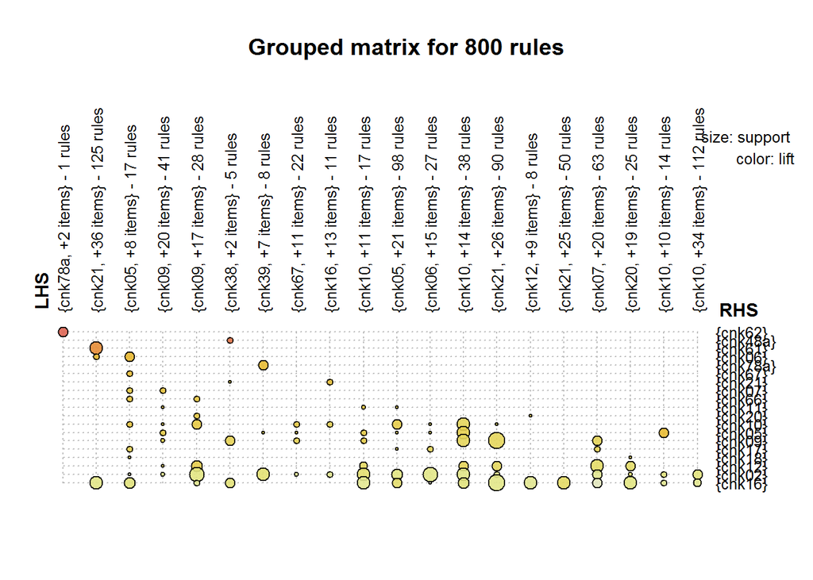

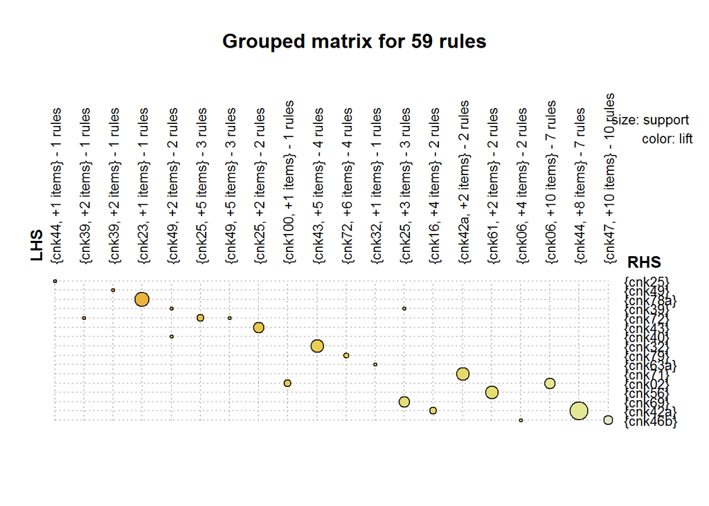

Przeprowadzimy teraz analizę dla klastrów 1-3 dla grupy gości odwiedzających 15-19 stacji.

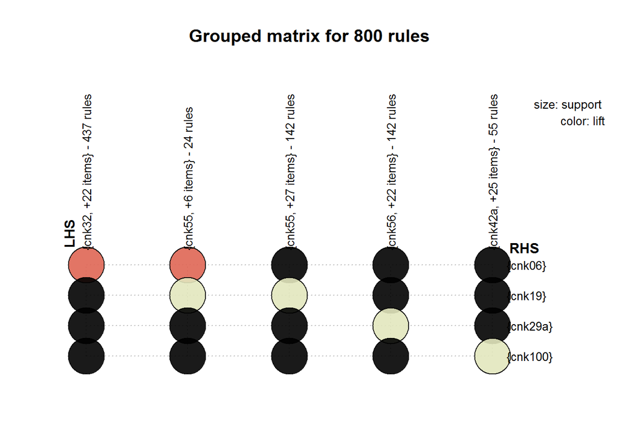

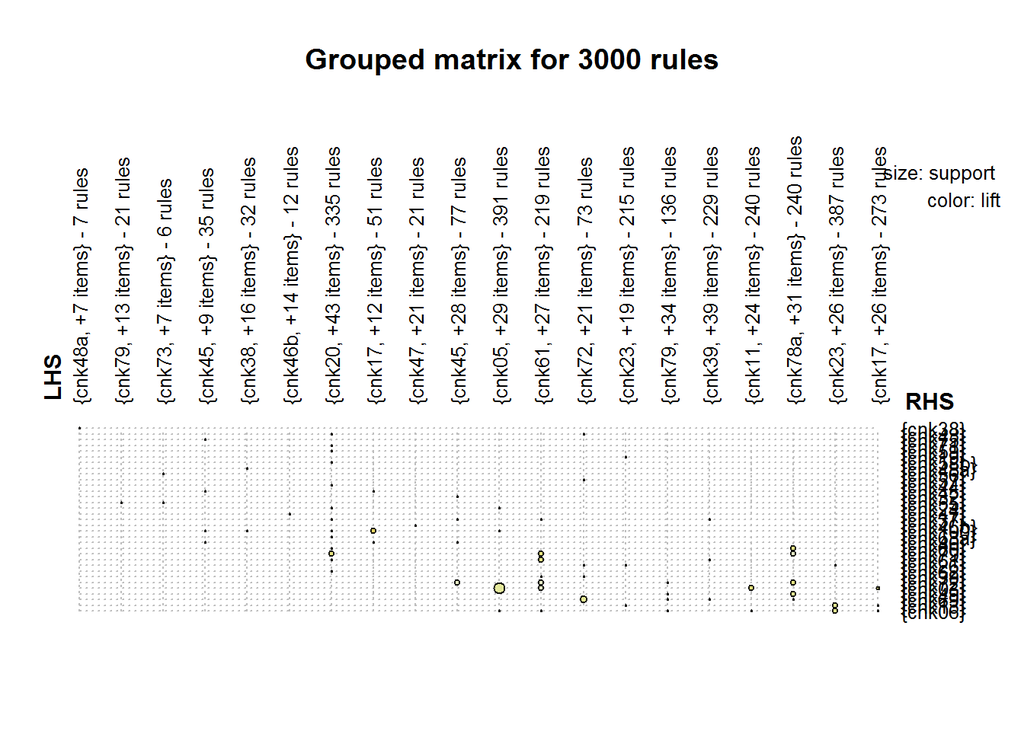

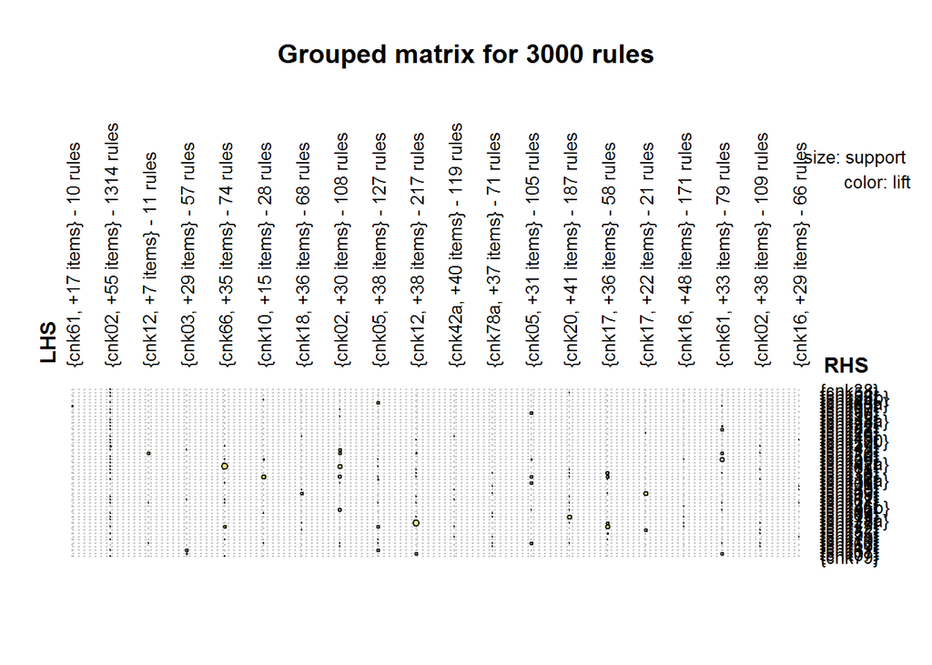

Pozostaje jeszcze sprawdzić gości odwiedzających +20 stacji.

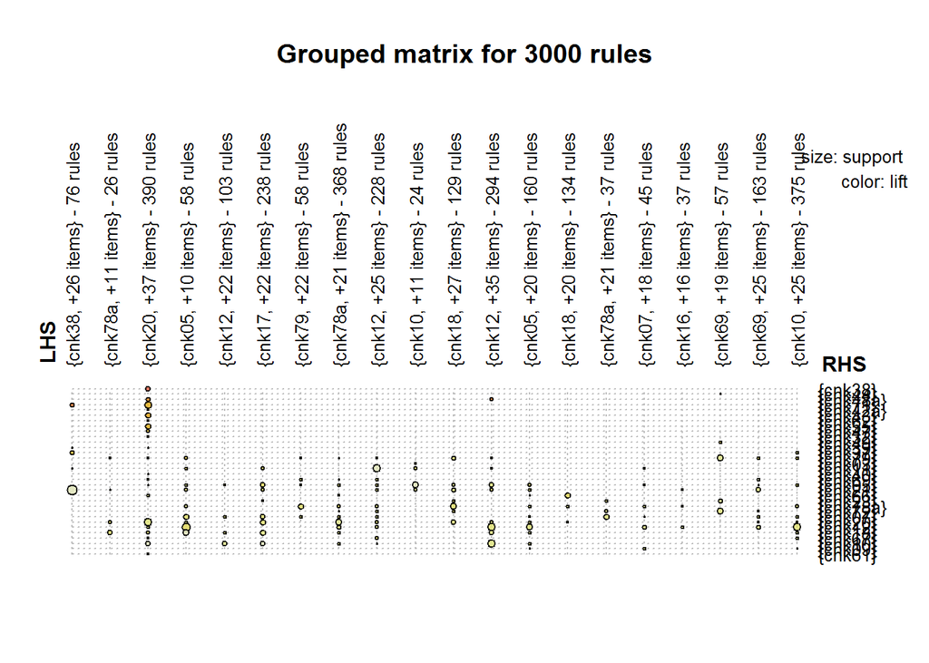

# Prosta regresja

Po analizie reguł warto się jeszcze zastanowić w jaki sposób odwiedzenie najpopularniejszych stacji wpływa na ogólną liczbę odwiedzonych stacji. W tym celu opracowano prosty model regresji linowej postaci:

liczba odwiedzonych stacji = {zbiór zmiennych kontrolnych} + (odwiedzenie stacji): cnk02 + cnk19 + cnk16 + cnk18 + cnk12

Za zmienne kontrolne przyjęto: a) dzień tygodnia (zbiór zmiennych binarnych, pominięto czwartek ze względu na współliniowość), b) godzina wejścia (znów zbiór zmiennych binarnych, pominięto 17 ze względu na współliniowość).

Analizie poddano jedynie tych gości, którzy odwiedzili co najmniej 10 stacji. W tym zbiorze zastosowanie regresji jest bardziej uprawnione niż w przypadku wszystkich gości, gdyż osoby te prawdopodobnie bardziej uważnie zwiedzały ekspozycję i wybór odwiedzonych stacji był mniej przypadkowy. Z drugiej strony, by zachować różnorodność liczby odwiedzonych stacji, nie dzielono wybranego zbioru odwiedzających na kolejne podzbiory.

Oszacowano dwa modele: w pierwszym - przez liczbę odwiedzonych stacji rozumiemy wszystkie stacje,w drugim - stacje nienależące do najpopularniejszych. Modele zostały oszacowane jedynie w celu wykazania istnienia oraz znalezienia kierunku związku między zmiennymi objaśniającymi a zmienną objaśnianą. Nie mają jednak wartości prognostycznej.

```
##
## Call:
## lm(formula = suma ~ cnk16 + cnk19 + cnk02 + cnk12 + cnk18 + n +
##     p + w + s + pi1 + so1 + g8 + g9 + g10 + g11 + g12 + g13 +
##     g14 + g15 + g16 + g18 + g19 + g20 + g21, data = B)
##
## Residuals:
##      Min       1Q   Median       3Q      Max
## -10.2519  -3.1582  -0.9684   2.1784  30.0673
##
## Coefficients: (2 not defined because of singularities)
##             Estimate Std. Error t value Pr(>|t|)
## (Intercept)  9.72970    0.26285  37.016  < 2e-16 ***
## cnk16        1.75526    0.09682  18.129  < 2e-16 ***
## cnk19        1.13071    0.09680  11.681  < 2e-16 ***
## cnk02        1.36525    0.09500  14.370  < 2e-16 ***
## cnk12        2.44904    0.09740  25.145  < 2e-16 ***
## cnk18        1.85013    0.09668  19.136  < 2e-16 ***
## n            0.34648    0.16383   2.115 0.034471 *
## p                 NA         NA      NA       NA
## w            0.09503    0.17117   0.555 0.578788
## s            0.12158    0.16904   0.719 0.472002
## pi1          0.07930    0.15219   0.521 0.602333
## so1          0.35924    0.15418   2.330 0.019825 *
## g8           0.88584    2.36818   0.374 0.708369
## g9           1.42926    0.38201   3.741 0.000184 ***
## g10          1.89253    0.27092   6.985 3.02e-12 ***
## g11          1.56814    0.25123   6.242 4.50e-10 ***
## g12          1.57334    0.24810   6.342 2.37e-10 ***
## g13          1.49536    0.25101   5.957 2.65e-09 ***
## g14          1.31259    0.25169   5.215 1.87e-07 ***
## g15          1.15944    0.25153   4.609 4.09e-06 ***
## g16          0.64774    0.25909   2.500 0.012434 *
## g18         -1.61148    0.53712  -3.000 0.002704 **
## g19               NA         NA      NA       NA
## g20          2.11316    3.34190   0.632 0.527190
## g21         -0.55173    2.73218  -0.202 0.839968
## ---
## Signif. codes:  0 '***' 0.001 '**' 0.01 '*' 0.05 '.' 0.1 ' ' 1
##
## Residual standard error: 4.711 on 10127 degrees of freedom
## Multiple R-squared:  0.1903, Adjusted R-squared:  0.1885
## F-statistic: 108.2 on 22 and 10127 DF,  p-value: < 2.2e-16
```

```
##
## Call:
## lm(formula = suma1 ~ cnk16 + cnk19 + cnk02 + cnk12 + cnk18 +
##     n + w + s + pi1 + so1 + g8 + g9 + g10 + g11 + g12 + g13 +
##     g14 + g15 + g16 + g18 + g19 + g20 + g21, data = B)
##
## Residuals:
##      Min       1Q   Median       3Q      Max
## -10.2503  -3.1657  -0.9492   2.1821  28.9965
##
## Coefficients: (1 not defined because of singularities)
##             Estimate Std. Error t value Pr(>|t|)
## (Intercept)  9.80266    0.26167  37.463  < 2e-16 ***
## cnk16        0.71581    0.09638   7.427 1.20e-13 ***
## cnk19       -0.58550    0.09636  -6.076 1.28e-09 ***
## cnk02        0.19137    0.09458   2.023  0.04306 *
## cnk12        1.43555    0.09696  14.806  < 2e-16 ***
## cnk18        0.84606    0.09625   8.790  < 2e-16 ***
## n            0.25892    0.16310   1.588  0.11243
## w            0.12655    0.17040   0.743  0.45769
## s            0.14049    0.16828   0.835  0.40380
## pi1          0.05093    0.15151   0.336  0.73676
## so1          0.26932    0.15348   1.755  0.07934 .
## g8           0.85501    2.35752   0.363  0.71686
## g9           1.54453    0.38029   4.061 4.91e-05 ***
## g10          1.91427    0.26970   7.098 1.35e-12 ***
## g11          1.57507    0.25010   6.298 3.15e-10 ***
## g12          1.54657    0.24698   6.262 3.96e-10 ***
## g13          1.45639    0.24988   5.828 5.77e-09 ***
## g14          1.30496    0.25056   5.208 1.94e-07 ***
## g15          1.11346    0.25040   4.447 8.81e-06 ***
## g16          0.61666    0.25793   2.391  0.01683 *
## g18         -1.70590    0.53470  -3.190  0.00143 **
## g19               NA         NA      NA       NA
## g20          2.28573    3.32685   0.687  0.49206
## g21         -0.33240    2.71988  -0.122  0.90273
## ---
## Signif. codes:  0 '***' 0.001 '**' 0.01 '*' 0.05 '.' 0.1 ' ' 1
##
## Residual standard error: 4.69 on 10127 degrees of freedom
## Multiple R-squared:  0.05645,    Adjusted R-squared:  0.05441
## F-statistic: 27.54 on 22 and 10127 DF,  p-value: < 2.2e-16
```

# Podsumowanie

Przeprowadzona analiza pokazała, że niemożliwa jest jednoznaczna odpowiedź na pytanie czy dana stacja jest “tranzytowa” czy “inspirująca”. Możliwe jest natomiast określenie, która ze stacji jest bardziej zbliżona do określonych przez nas typów (stacje ułożone przez nas w kolejności od najbardziej tranzytowych do najbardziej inspirujących):

cnk19 - tę stację można określić jako najbardziej “tranzytową”. Mimo tego, że większość gości zaraz po jej opuszczeniu kierowała się do mało- i średnio-popularnych stacji oraz tego, że analiza sekwencji odnalazła kilka reguł łączących cnk19 z mniej popularnymi stacjami, to pozostałe analizy wskazały tę ekspozycję jako wyjątkowo mało inspirującą. Reguły asocjacyjne łączyły cnk19 jedynie z popularną stacją cnk02. Również regresje wskazały, że stacja ta miała negatywny (lub najmniej pozytywny) wpływ na liczbę odwiedzonych przez gości stacji. Wydaje się więc, że odwiedzający wychodzą z tej stacji w przypadkowych kierunkach i trudno uznać, by czuli się w szczególny sposób zainspirowani do zobaczenia jakichś konkretnych ekspozycji.

cnk16 - reguły asocjacyjne łączyły tę stację jedynie z innymi popularnymi stacjami, względnie najmniej osób przeszło z niej do ekspozycji średnio lub mało popularnych. Z tych względów uznaliśmy cnk16 za bardziej “tranzytową” niż “inspirującą”.

cnk02- najbardziej zagadkowa stacja. Analiza reguł asocjacyjnych bez kolejności wskazała, że wpływ tej stacji jest silny jedynie w określonych klastrach (określonych dla osób odwiedzających przynajmniej 10 stacji). Analiza sekwencji wykazała natomiast, że stacja ta silnie oddziałuje na zwiedzających - wynik ten może być jednak spowodowany tym, że większość z nich zaczyna zwiedzanie właśnie od cnk02. W pozostałych analizach stacja ta ujawniła mało charakterystyczne właściwości. Dlatego też znajduje się w środku naszego zestawienia.

cnk12 - stacja ta występowała po lewej stronie bardzo wielu reguł, zarówno dla całej populacji, jak i dla wielu klastrów. Także współczynniki w obu regresjach wskazywały na pozytywny wpływ stacji cnk12. Analiza sekwencji nie ujawniła natomiast żadnych sposobów zwiedzania, zaczynających się od tej stacji. Dlatego umieściliśmy ją na drugim miejscu.

cnk18 - zarówno analizy reguł asocjacyjnych bez kolejności jak i reguł dla sekwencji (w dużo mniejszym stopniu) ujawniły, że stacja ta ma silny wpływ, inspirujący do odwiedzenia mniej popularnych stacji, najbardziej widoczny wśród zwiedzających powyżej 10 eksponatów. Również z tej stacji najwięcej gości skierowało się do stacji mniej popularnych (choć, w pewnym stopniu, może to być wynikiem układu eksponatów). Również współczynniki w obu regresjach wskazywały na pozytywny wpływ tej stacji. Wobec tego uznaliśmy ją za najbardziej inspirującą.